# HW2-EDA with R - Part1: Plotting

Nivedita Chawdhari

February 11, 2018

## Step 1 - Familiarize yourself with the data and the assignment

### [Kaggle Data Set](https://www.kaggle.com/muonneutrino/us-census-demographic-data/data)

## Step 2 - Create a new R Markdown document

RMD File : **HW2_EDAwR_Chawdhari.Rmd**

Working Directory : **HW2_files**

**[GitHub URL](https://github.com/nivi1990/HW2_Chawdhari)**

## Step 3 - Set working directory and explore data folder

Data files for this assignment:

- **acs2015_census_tract_data.csv**
- **acs2015_county_data.csv**
- **us_census_bureau_regions_and_divisions.csv**
- **county.csv**
- **county_MI.csv**

The first two files are from the Kaggle site for this dataset. The two files, **county.csv** and **county_MI.csv**, are files that I created. The first contains county level data from all states and the other just data from Michigan. The R script, **census_data_prep.R** was used to create these files and to merge information from the **us_census_bureau_regions_and_divisions.csv** file with the county data.

## Step 4 - Complete the following R tasks and answer questions

Let’s load a few libraries we’ll need:

```r
library(dplyr)
```

```r
library(ggplot2)
library(reshape2)
library(ggcorrplot)
```

### Problem 1 - Get the data into a dataframe

You should read the **county.csv** file into a data frame named county_df and **county_MI.csv** into a data frame named county_MI.

```r
 county_df <- read.csv("data/county.csv")
county_MI <- read.csv("data/county_MI.csv")
```

Are there any NA values? What differences do you notice between the structure of the two data frames?

### **Structure and Summary Check for the Dataframes:**

```r
str(county_df)
```

```
## 'data.frame':    3142 obs. of  40 variables:
##  $ State          : Factor w/ 51 levels "Alabama","Alaska",..: 1 1 1 1 1 1 1 1 1 1 ...
##  $ CensusId       : int  1055 1133 1053 1001 1003 1005 1007 1009 1011 1013 ...
##  $ State.Code     : Factor w/ 51 levels "AK","AL","AR",..: 2 2 2 2 2 2 2 2 2 2 ...
##  $ Region         : Factor w/ 4 levels "Midwest","Northeast",..: 3 3 3 3 3 3 3 3 3 3 ...
##  $ Division       : Factor w/ 9 levels "East North Central",..: 2 2 2 2 2 2 2 2 2 2 ...
##  $ County         : Factor w/ 1851 levels "Abbeville","Acadia",..: 557 1810 553 82 89 100 149 164 225 235 ...
##  $ TotalPop       : int  103766 24130 37935 55221 195121 26932 22604 57710 10678 20354 ...
##  $ Men            : int  50207 11876 19524 26745 95314 14497 12073 28512 5660 9502 ...
##  $ Women          : int  53559 12254 18411 28476 99807 12435 10531 29198 5018 10852 ...
##  $ Hispanic       : num  3.6 2.8 1.2 2.6 4.5 4.6 2.2 8.6 4.4 1.2 ...
##  $ White          : num  78.5 94.3 60.7 75.8 83.1 46.2 74.5 87.9 22.2 53.3 ...
##  $ Black          : num  15.4 0.5 33.4 18.5 9.5 46.7 21.4 1.5 70.7 43.8 ...
##  $ Native         : num  0.3 0.3 3.2 0.4 0.6 0.2 0.4 0.3 1.2 0.1 ...
##  $ Asian          : num  0.7 0.2 0.1 1 0.7 0.4 0.1 0.1 0.2 0.4 ...
```

[output cut: 26 more lines]

```r
str(county_MI)
```

```
## 'data.frame':    83 obs. of  41 variables:
##  $ County         : Factor w/ 83 levels "Alcona","Alger",..: 1 2 3 4 5 6 7 8 9 10 ...
##  $ peninsula      : Factor w/ 2 levels "LP","UP": 1 2 1 1 1 1 2 1 1 1 ...
##  $ State          : Factor w/ 1 level "Michigan": 1 1 1 1 1 1 1 1 1 1 ...
##  $ CensusId       : int  26001 26003 26005 26007 26009 26011 26013 26015 26017 26019 ...
##  $ State.Code     : Factor w/ 1 level "MI": 1 1 1 1 1 1 1 1 1 1 ...
##  $ Region         : Factor w/ 1 level "Midwest": 1 1 1 1 1 1 1 1 1 1 ...
##  $ Division       : Factor w/ 1 level "East North Central": 1 1 1 1 1 1 1 1 1 1 ...
##  $ TotalPop       : int  10550 9476 112837 29068 23267 15424 8690 59147 106698 17437 ...
##  $ Men            : int  5310 5218 56205 14276 11587 7813 5265 29733 52513 8708 ...
##  $ Women          : int  5240 4258 56632 14792 11680 7611 3425 29414 54185 8729 ...
##  $ Hispanic       : num  1.4 1.3 7 1.2 1.9 1.8 1.3 2.5 5 2.1 ...
##  $ White          : num  96.3 84.8 89.1 96.1 95.2 95.2 73.3 94.9 90.6 94.3 ...
##  $ Black          : num  0.3 7.7 1.4 0.5 0.3 0.5 18.3 0.5 1.3 0.3 ...
##  $ Native         : num  0.2 2.6 0.5 0.6 0.9 1.3 4.5 0.2 0.2 1.2 ...
```

[output cut: 27 more lines]

```r
summary(county_df)
```

```
##       State         CensusId       State.Code         Region
##  Texas   : 254   Min.   : 1001   TX     : 254   Midwest  :1055
##  Georgia : 159   1st Qu.:18178   GA     : 159   Northeast: 217
##  Virginia: 133   Median :29176   VA     : 133   South    :1422
##  Kentucky: 120   Mean   :30384   KY     : 120   West     : 448
##  Missouri: 115   3rd Qu.:45080   MO     : 115
##  Kansas  : 105   Max.   :56045   KS     : 105
##  (Other) :2256                   (Other):2256
##                Division          County        TotalPop
##  West North Central:618   Washington:  31   Min.   :      85
##  South Atlantic    :588   Jefferson :  26   1st Qu.:   11028
##  West South Central:470   Franklin  :  25   Median :   25768
##  East North Central:437   Jackson   :  24   Mean   :  100737
##  East South Central:364   Lincoln   :  24   3rd Qu.:   67552
##  Mountain          :281   Madison   :  20   Max.   :10038388
##  (Other)           :384   (Other)   :2992
##       Men              Women            Hispanic          White
##  Min.   :     42   Min.   :     43   Min.   : 0.000   Min.   : 0.90
##  1st Qu.:   5546   1st Qu.:   5466   1st Qu.: 1.900   1st Qu.:65.60
##  Median :  12826   Median :  12907   Median : 3.700   Median :84.60
##  Mean   :  49565   Mean   :  51171   Mean   : 8.826   Mean   :77.28
##  3rd Qu.:  33319   3rd Qu.:  34122   3rd Qu.: 9.000   3rd Qu.:93.30
##  Max.   :4945351   Max.   :5093037   Max.   :98.700   Max.   :99.80
##
##      Black            Native           Asian           Pacific
##  Min.   : 0.000   Min.   : 0.000   Min.   : 0.000   Min.   : 0.00000
##  1st Qu.: 0.600   1st Qu.: 0.100   1st Qu.: 0.200   1st Qu.: 0.00000
##  Median : 2.100   Median : 0.300   Median : 0.500   Median : 0.00000
##  Mean   : 8.879   Mean   : 1.766   Mean   : 1.258   Mean   : 0.08475
##  3rd Qu.:10.175   3rd Qu.: 0.600   3rd Qu.: 1.200   3rd Qu.: 0.00000
##  Max.   :85.900   Max.   :92.100   Max.   :41.600   Max.   :35.30000
##
##     Citizen            Income         IncomeErr      IncomePerCap
##  Min.   :     80   Min.   : 19328   Min.   :  270   Min.   : 8292
##  1st Qu.:   8254   1st Qu.: 38826   1st Qu.: 1677   1st Qu.:20471
##  Median :  19434   Median : 45111   Median : 2435   Median :23577
##  Mean   :  70804   Mean   : 46830   Mean   : 2885   Mean   :24338
##  3rd Qu.:  50728   3rd Qu.: 52250   3rd Qu.: 3484   3rd Qu.:27138
##  Max.   :6046749   Max.   :123453   Max.   :21355   Max.   :65600
##                    NA's   :1        NA's   :1
```

[output cut: 33 more lines]

```
##  Min.   :25.00   Min.   : 5.80   Min.   : 0.000   Min.   :0.0000
##  1st Qu.:70.90   1st Qu.:13.10   1st Qu.: 5.400   1st Qu.:0.1000
##  Median :75.80   Median :16.10   Median : 6.900   Median :0.2000
##  Mean   :74.44   Mean   :17.35   Mean   : 7.921   Mean   :0.2915
##  3rd Qu.:79.80   3rd Qu.:20.10   3rd Qu.: 9.400   3rd Qu.:0.3000
##  Max.   :88.30   Max.   :66.20   Max.   :36.600   Max.   :9.8000
##
##   Unemployment
##  Min.   : 0.000
##  1st Qu.: 5.500
##  Median : 7.500
##  Mean   : 7.815
##  3rd Qu.: 9.700
##  Max.   :29.400
##
```

```r
summary(county_MI)
```

```
##      County   peninsula      State       CensusId     State.Code
##  Alcona : 1   LP:68     Michigan:83   Min.   :26001   MI:83
##  Alger  : 1   UP:15                   1st Qu.:26042
##  Allegan: 1                           Median :26083
##  Alpena : 1                           Mean   :26083
##  Antrim : 1                           3rd Qu.:26124
##  Arenac : 1                           Max.   :26165
##  (Other):77
##      Region                 Division     TotalPop            Men
##  Midwest:83   East North Central:83   Min.   :   2198   Min.   :  1145
##                                       1st Qu.:  22503   1st Qu.: 11152
##                                       Median :  38586   Median : 20843
##                                       Mean   : 119284   Mean   : 58578
##                                       3rd Qu.:  94404   3rd Qu.: 47354
##                                       Max.   :1778969   Max.   :855112
##
##      Women           Hispanic          White           Black
##  Min.   :  1053   Min.   : 0.900   Min.   :49.80   Min.   : 0.200
##  1st Qu.: 11280   1st Qu.: 1.550   1st Qu.:85.00   1st Qu.: 0.500
##  Median : 18540   Median : 2.500   Median :91.90   Median : 1.300
##  Mean   : 60706   Mean   : 3.307   Mean   :88.45   Mean   : 3.917
##  3rd Qu.: 47153   3rd Qu.: 4.350   3rd Qu.:94.95   3rd Qu.: 4.600
##  Max.   :923857   Max.   :14.200   Max.   :97.80   Max.   :39.200
##
##      Native           Asian           Pacific           Citizen
##  Min.   : 0.100   Min.   :0.0000   Min.   :0.00000   Min.   :   1814
##  1st Qu.: 0.300   1st Qu.:0.3000   1st Qu.:0.00000   1st Qu.:  17656
##  Median : 0.500   Median :0.5000   Median :0.00000   Median :  30237
##  Mean   : 1.259   Mean   :0.9759   Mean   :0.01325   Mean   :  88917
##  3rd Qu.: 1.100   3rd Qu.:0.8000   3rd Qu.:0.00000   3rd Qu.:  72964
##  Max.   :15.700   Max.   :8.4000   Max.   :0.20000   Max.   :1287373
##
##      Income        IncomeErr     IncomePerCap   IncomePerCapErr
##  Min.   :30439   Min.   : 304   Min.   :16679   Min.   : 161.0
##  1st Qu.:39338   1st Qu.:1233   1st Qu.:21214   1st Qu.: 543.0
##  Median :42161   Median :1449   Median :23139   Median : 693.0
##  Mean   :44465   Mean   :1563   Mean   :23662   Mean   : 830.1
##  3rd Qu.:47760   3rd Qu.:1756   3rd Qu.:25201   3rd Qu.:1007.0
##  Max.   :75204   Max.   :4009   Max.   :37728   Max.   :2719.0
##
```

[output cut: 25 more lines]

```
##  Min.   :2.200   Min.   :14.50   Min.   :   842   Min.   :63.70
##  1st Qu.:3.350   1st Qu.:20.20   1st Qu.:  8196   1st Qu.:77.05
##  Median :4.000   Median :22.40   Median : 15869   Median :80.40
##  Mean   :4.235   Mean   :22.89   Mean   : 52693   Mean   :79.68
##  3rd Qu.:4.700   3rd Qu.:25.50   3rd Qu.: 43450   3rd Qu.:83.25
##  Max.   :9.800   Max.   :33.50   Max.   :696900   Max.   :87.30
##
##    PublicWork     SelfEmployed      FamilyWork      Unemployment
##  Min.   : 7.70   Min.   : 3.800   Min.   :0.0000   Min.   : 5.900
##  1st Qu.:10.90   1st Qu.: 5.100   1st Qu.:0.1000   1st Qu.: 8.350
##  Median :11.90   Median : 6.600   Median :0.2000   Median : 9.700
##  Mean   :13.52   Mean   : 6.517   Mean   :0.2952   Mean   : 9.963
##  3rd Qu.:15.40   3rd Qu.: 7.400   3rd Qu.:0.3500   3rd Qu.:11.550
##  Max.   :29.50   Max.   :10.200   Max.   :2.0000   Max.   :16.000
##
```

```r
#Replacing NA's with Mean
county_df$Income <- ifelse(is.na(county_df$Income), mean(county_df$Income, na.rm=TRUE), county_df$Income)
county_df$IncomeErr <- ifelse(is.na(county_df$IncomeErr), mean(county_df$IncomeErr, na.rm=TRUE), county_df$IncomeErr)
county_df$ChildPoverty <- ifelse(is.na(county_df$ChildPoverty), mean(county_df$ChildPoverty, na.rm=TRUE), county_df$ChildPoverty)
```

### Problem 2 - Basic plots for Income

Create a histogram, boxplot, kernel density plot and violin plot for median income for the entire US.Write a short paragraph describing the distribution of median incomes.

- **50 % of the people have median household income from 38826.25 to 52249.25**
- **There are many outliers on the higher side i.e people earning more than 75000**
- **The histogram is skewed to the right.**
- **There is an income inequality,this can be seen from the box plot,range for 4 th quartile is way greater than combined range for first 3** **quartiles i.e 75% of the people had a household income that falls between a short range while household income for rest 25% is spread out**

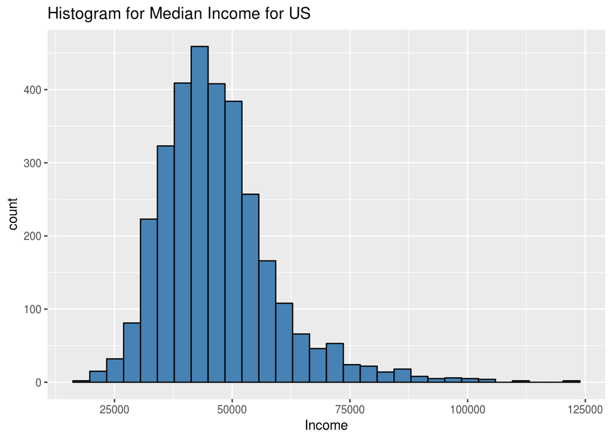

```r
#Histogram
ggplot(data=county_df, aes(county_df$Income)) +
  geom_histogram(fill="Steel Blue" ,color="Black")+
  labs(title="Histogram for Median Income for US" , x="Income")
```

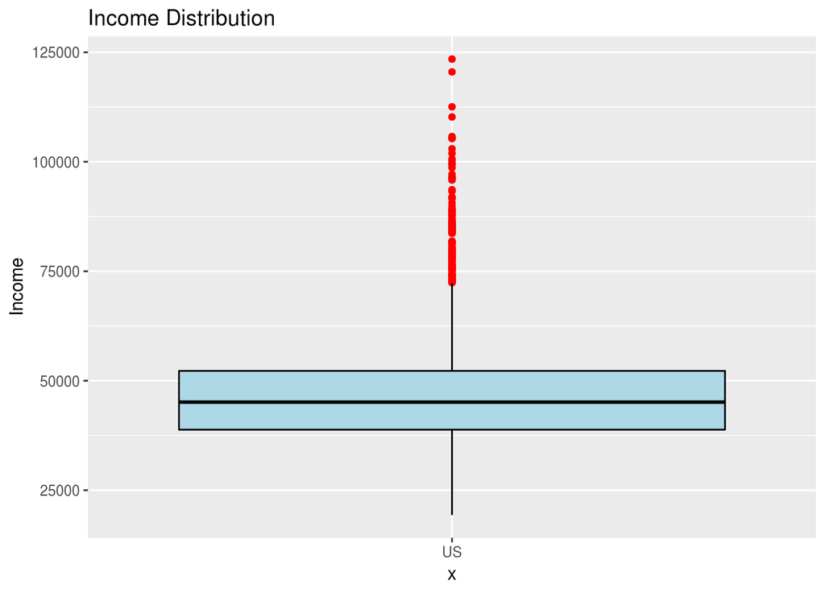

```r
#Box Plot
ggplot(data =  county_df, aes(x = "US",y = county_df$Income)) +
  geom_boxplot(colour="black",fill="light blue",outlier.colour = "red")+
  labs(title = "Income Distribution", y="Income" )
```

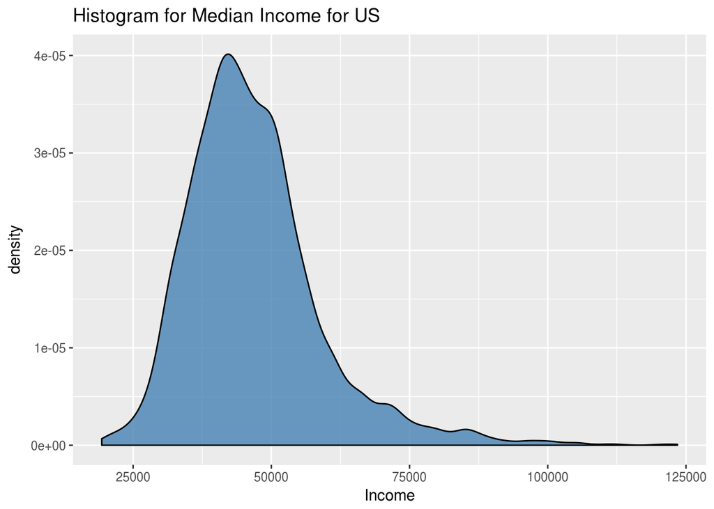

```r
#Denisity Plot
ggplot(data=county_df, aes(county_df$Income)) +
  geom_density(fill="Steel Blue",alpha=0.8)+
  labs(title="Histogram for Median Income for US" , x="Income")
```

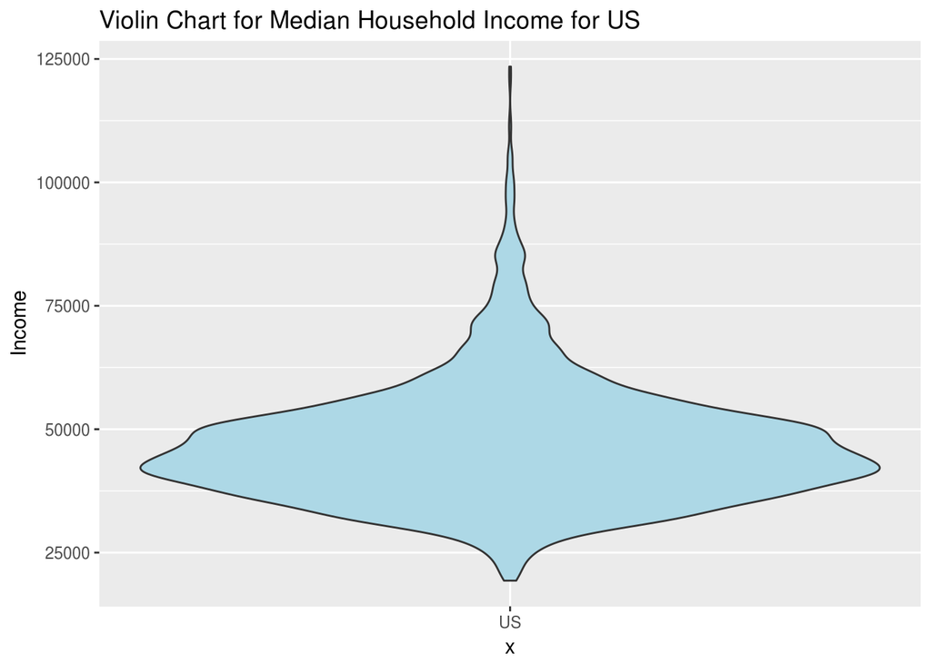

```r
#Violin Plot
ggplot(data=county_df, aes(y = county_df$Income,x = "US")) +
  geom_violin(fill="Light Blue") +
    labs(title="Violin Chart for Median Household Income for US" , y="Income")
```

```r
quantile(county_df$Income)
```

```
##        0%       25%       50%       75%      100%
##  19328.00  38826.25  45112.50  52249.25 123453.00
```

### Problem 3 - Histogram of total population

Create a histogram of total population for counties in the US.

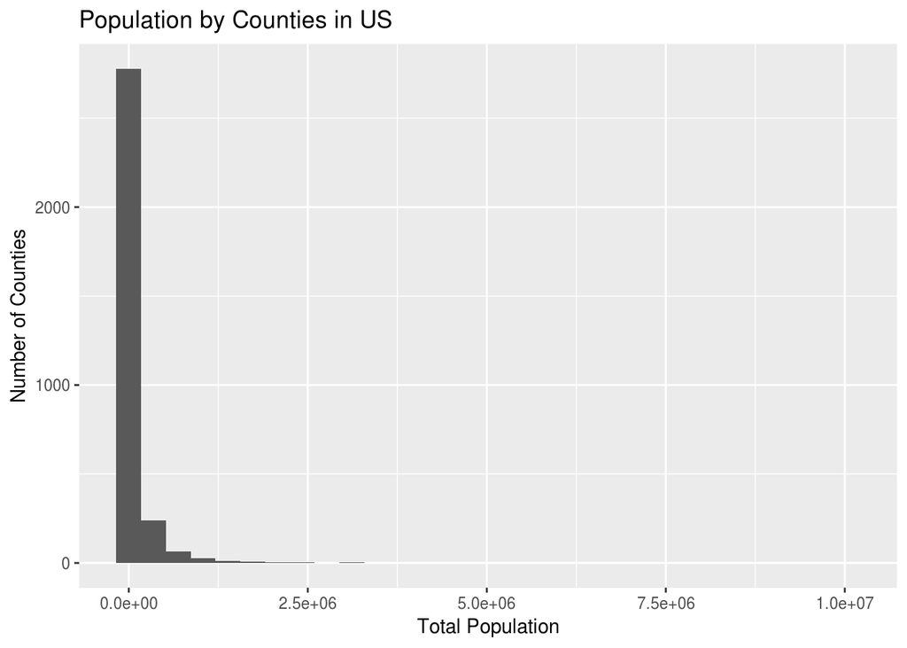

```r
ggplot(data=county_df, aes(county_df$TotalPop)) +
  geom_histogram()+
  labs(title="Population by Counties in US",x="Total Population",y="Number of Counties")
```

Repeat the histogram about but make the following style changes to the plot.

- Add a title such as “Distribution of population for US counties”
- Change y-axis label to “Number of counties”
- Change x-axis label to “Total Population”
- Change the colors of the bars to something other than the default black

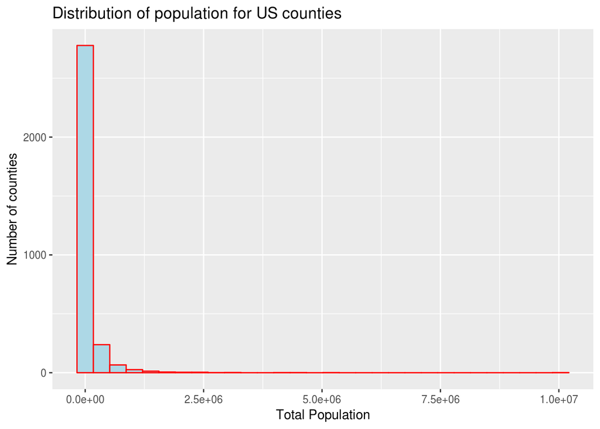

```r
ggplot(data=county_df, aes(county_df$TotalPop)) +
  geom_histogram(colour ="Red", fill ="light blue") +
  labs(title="Distribution of population for US counties" ,x="Total Population",y="Number of counties")
```

**Hacker Extra** -

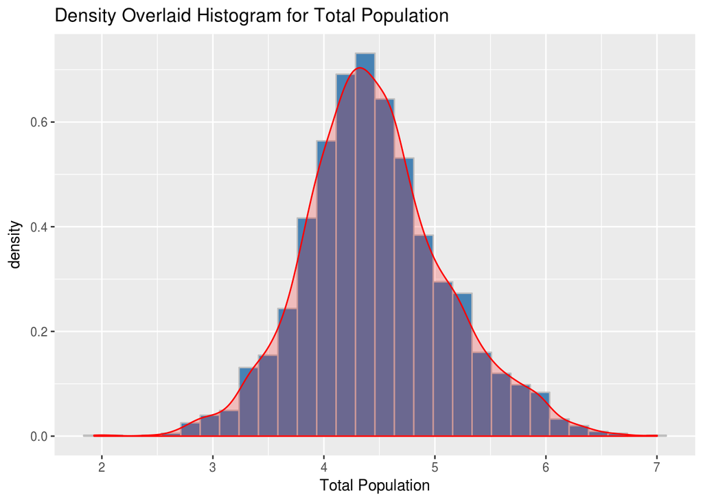

```r
 ggplot(county_df,aes(x=log10(county_df$TotalPop) )) +
  geom_histogram(aes(y=..density..),fill ="Steel Blue",color ="Gray")+
geom_density(color="Red",fill="Red",alpha=0.2) +
  labs(title="Density Overlaid Histogram for Total Population" ,x="Total Population")
```

Repeat the histogram but only for counties with less than 2.5 million people.

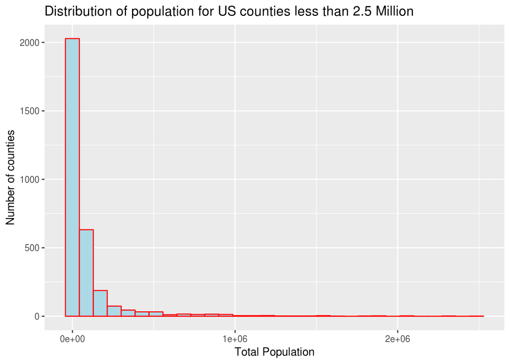

```r
ggplot(county_df[county_df$TotalPop < 2500000,],aes(x=TotalPop)) +
  geom_histogram(colour="red", fill ="Light Blue")+
  labs(title="Distribution of population for US counties less than 2.5 Million" ,x="Total Population",y="Number of counties")
```

### Problem 4 - How do Michigan’s peninsulas compare?

Create a grouped box plot showing Income by peninsula. Make sure your graph has a title and good axis labels.

Do the peninsulas differ with respect to distribution of median income over the counties?

**Yes ,the peninsulas do differe with respect to the median income:**

- **The range of income for lower peninsula is greater than that for upper peninsula**
- **Overal Income for Lower Peninsula is higher than that for Upper Peninsula**
- **There are a few extreme income values for lower peninusla while for Upper Peninsula there are no outliers**
- **There is more income inequality in Lower Peninsula as compared to Upper Peninsula,The Income for Upper Peninsula seems to uniformly distributed as compared to LP**

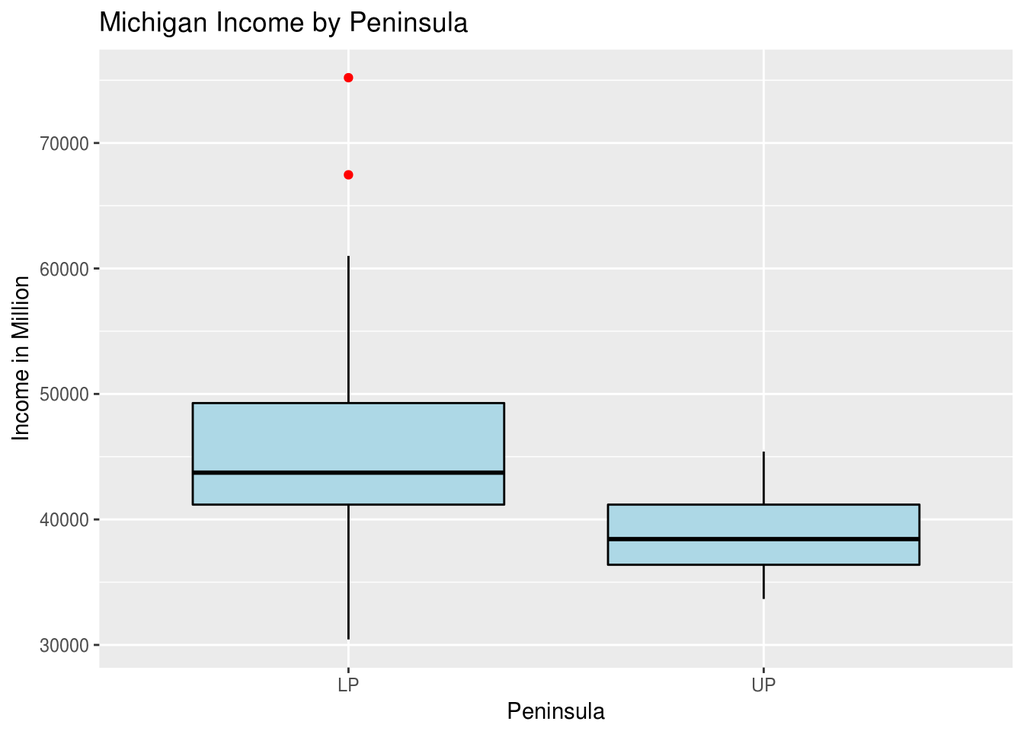

```r
ggplot(data =  county_MI, aes(x = county_MI$peninsula,y = county_MI$Income)) +
  geom_boxplot(colour="black",fill="light blue",outlier.colour = "red")+
  labs(title = "Michigan Income by Peninsula",x="Peninsula" , y="Income in Million" )
```

Create several more boxplots showing how the peninsulas compare with respect to some of the other variables. Summarize your findings in a few short paragraphs.

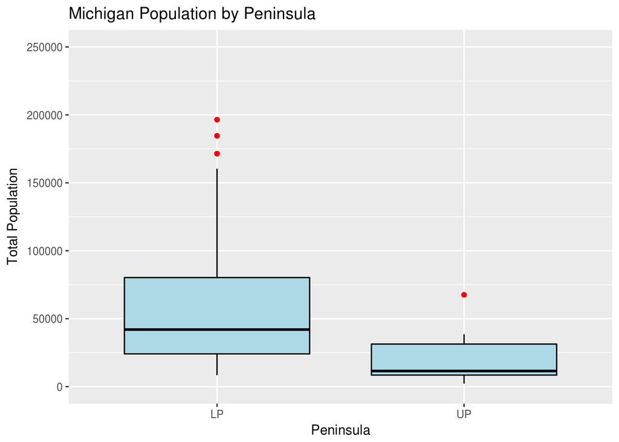

```r
#Boxplot for Total Population
ggplot(data =  county_MI, aes(x = county_MI$peninsula,y = county_MI$TotalPop)) +
  geom_boxplot(colour="black",fill="light blue",outlier.colour = "red")+
  scale_y_continuous(limits = c(0, 250000))+
  labs(title = "Michigan Population by Peninsula",x="Peninsula" , y="Total Population" )
```

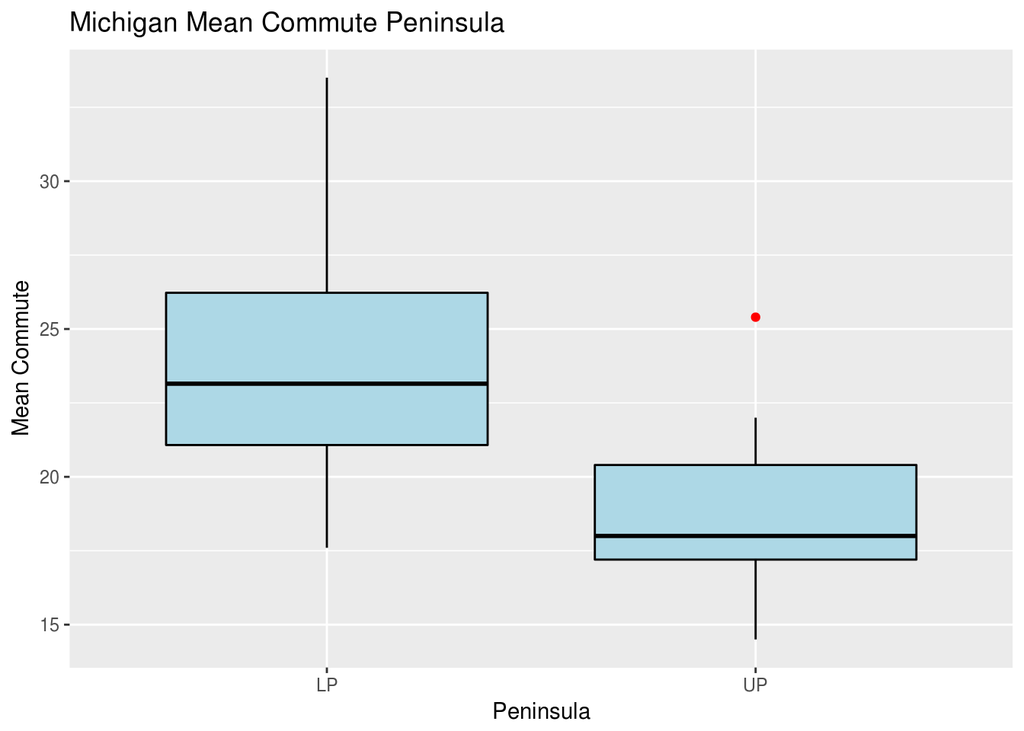

```r
#Boxplot for Mean Commute
ggplot(data =  county_MI, aes(x = county_MI$peninsula,y = county_MI$MeanCommute)) +
  geom_boxplot(colour="black",fill="light blue",outlier.colour = "red")+
  labs(title = "Michigan Mean Commute Peninsula",x="Peninsula" , y="Mean Commute" )
```

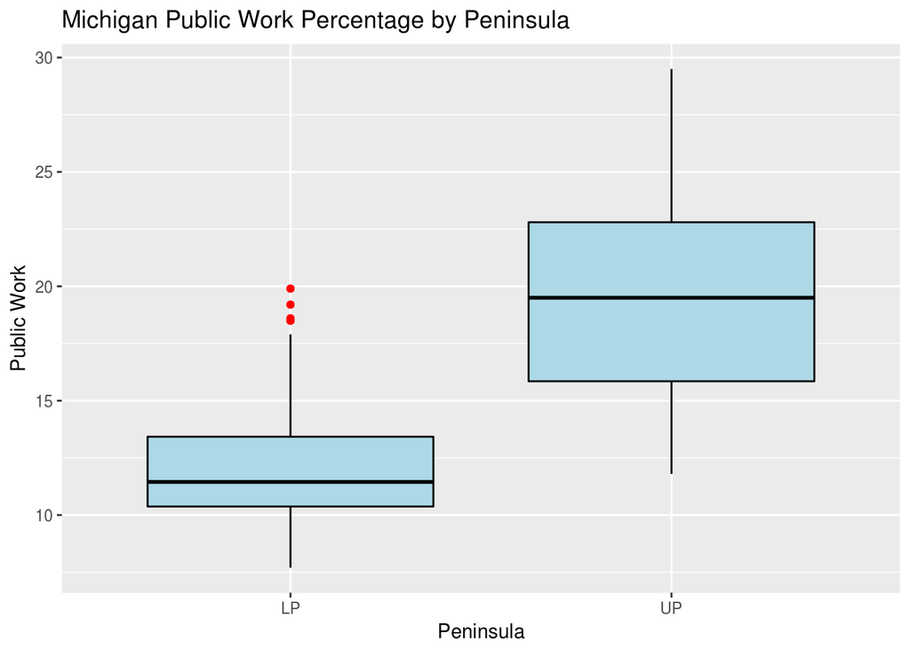

```r
#Boxplot for Public Work
ggplot(data =  county_MI, aes(x = county_MI$peninsula,y = county_MI$PublicWork)) +
  geom_boxplot(colour="black",fill="light blue",outlier.colour = "red")+
  labs(title = "Michigan Public Work Percentage by Peninsula",x="Peninsula" , y="Public Work" )
```

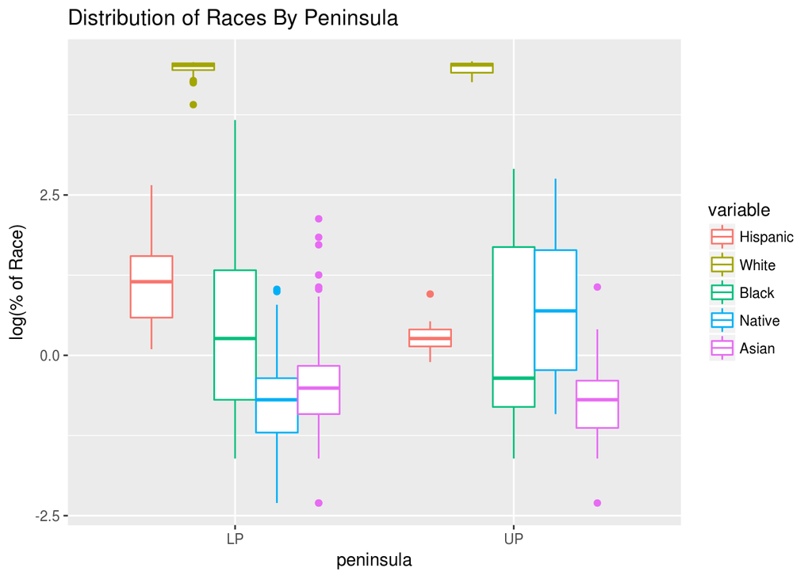

```r
#Grouped plot for Population Race
mdata <- melt(data = county_MI, id = 'peninsula', measure = c ('Hispanic','White','Black','Native','Asian'))
 ggplot(mdata) + geom_boxplot(aes(x=peninsula, y= log(value), color=variable)) +
  labs(title = "Distribution of Races By Peninsula" , y="log(% of Race)" )
```

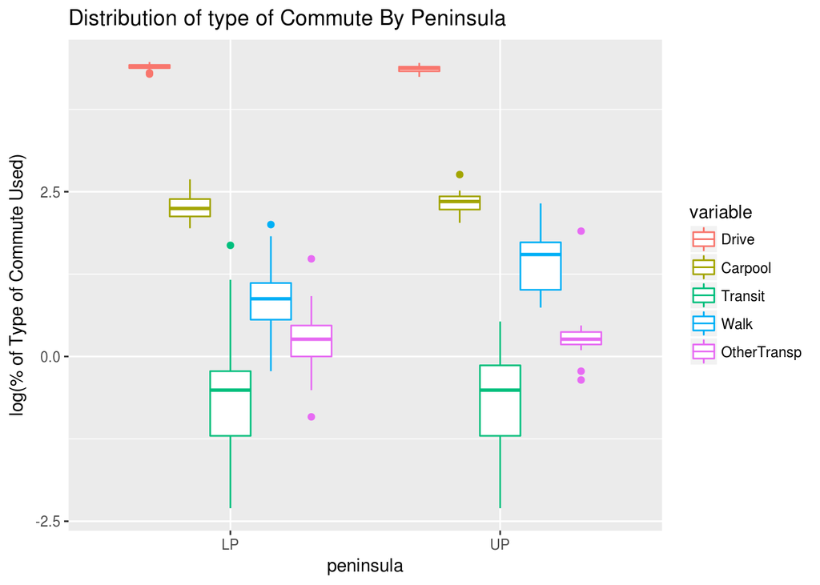

```r
 #Grouped Plot for Means of Commute
 mdata <- melt(data = county_MI, id = 'peninsula', measure = c ('Drive','Carpool','Transit','Walk','OtherTransp'))
 ggplot(mdata) + geom_boxplot(aes(x=peninsula, y=log(value), color=variable)) +
   labs(title = "Distribution of type of Commute By Peninsula" , y="log(% of Type of Commute Used)" )
```

### Problem 5 - How do regions of the country compare?

In county_df you’ll see that there’s a Region field. Create a set of faceted histograms showing how some variable of interest to you compares by region. For example, you could explore how the regions compare with respect to the distribution of MeanCommute time. Make sure your graph has a title and good axis labels.

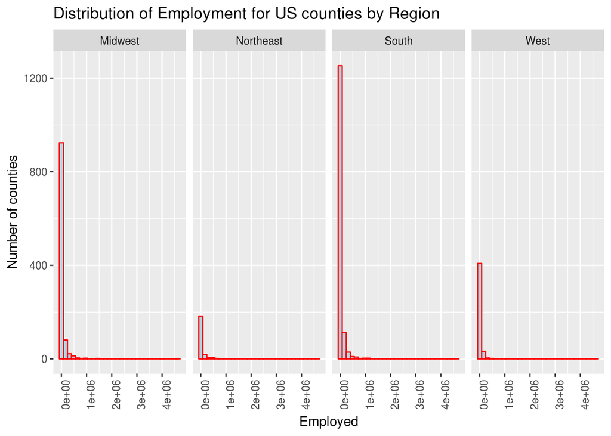

```r
ggplot(data=county_df, aes(county_df$Employed) ) +
  geom_histogram(colour ="Red", fill ="light blue") +
  labs(title="Distribution of Employment for US counties by Region" ,x="Employed",y="Number of counties") +
  theme(axis.text.x = element_text(angle=90))+
  facet_grid(. ~ Region)
```

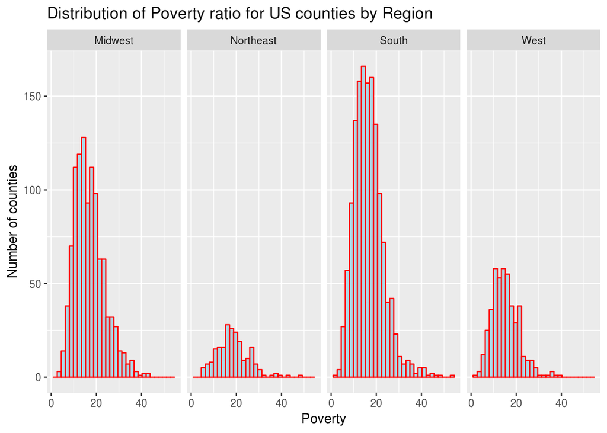

```r
ggplot(data=county_df, aes(county_df$Poverty)) +
  geom_histogram(colour ="Red", fill ="light blue") +
  labs(title="Distribution of Poverty ratio for US counties by Region" ,x="Poverty",y="Number of counties") +
  facet_grid(. ~ Region)
```

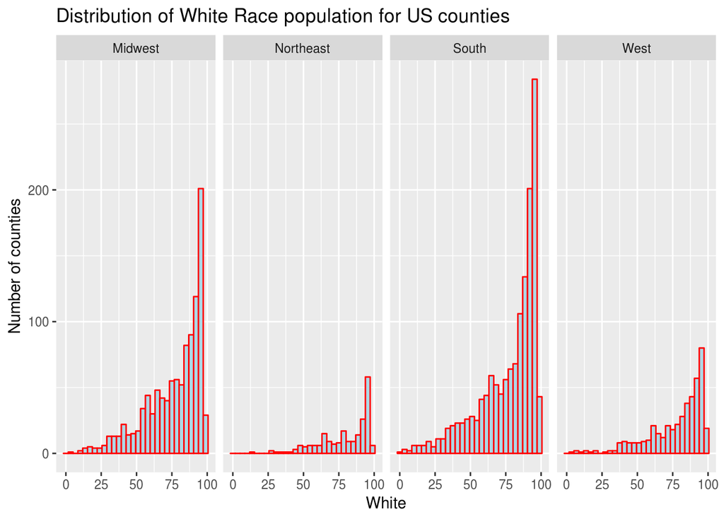

```r
ggplot(data=county_df, aes(county_df$White)) +
  geom_histogram(colour ="Red", fill ="light blue") +
  labs(title="Distribution of White Race population for US counties" ,x="White",y="Number of counties") +
  facet_grid(. ~ Region)
```

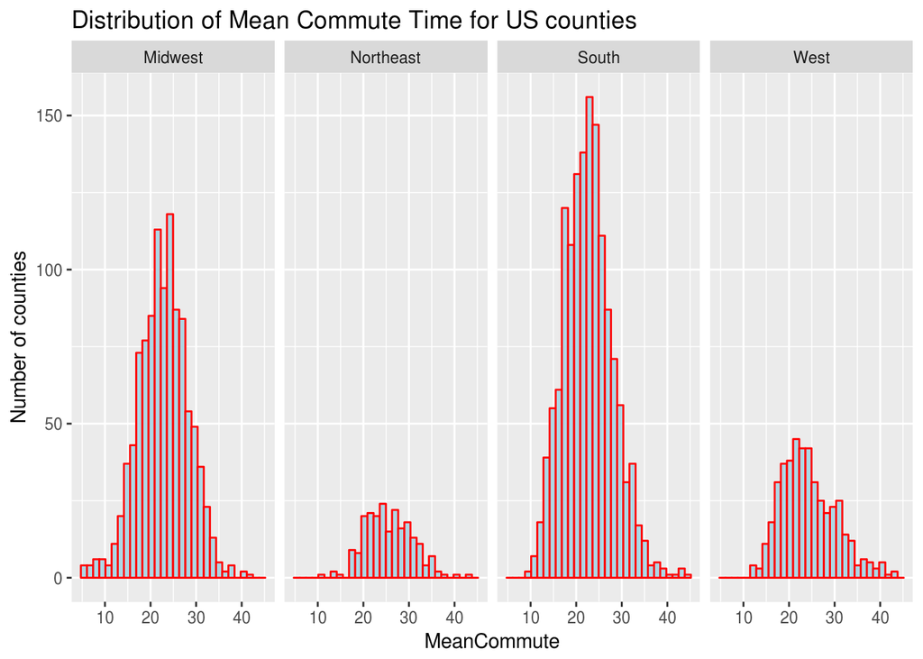

```r
ggplot(data=county_df, aes(county_df$MeanCommute)) +
  geom_histogram(colour ="Red", fill ="light blue") +
  labs(title="Distribution of Mean Commute Time for US counties" ,x="MeanCommute",y="Number of counties") +
  facet_grid(. ~ Region)
```

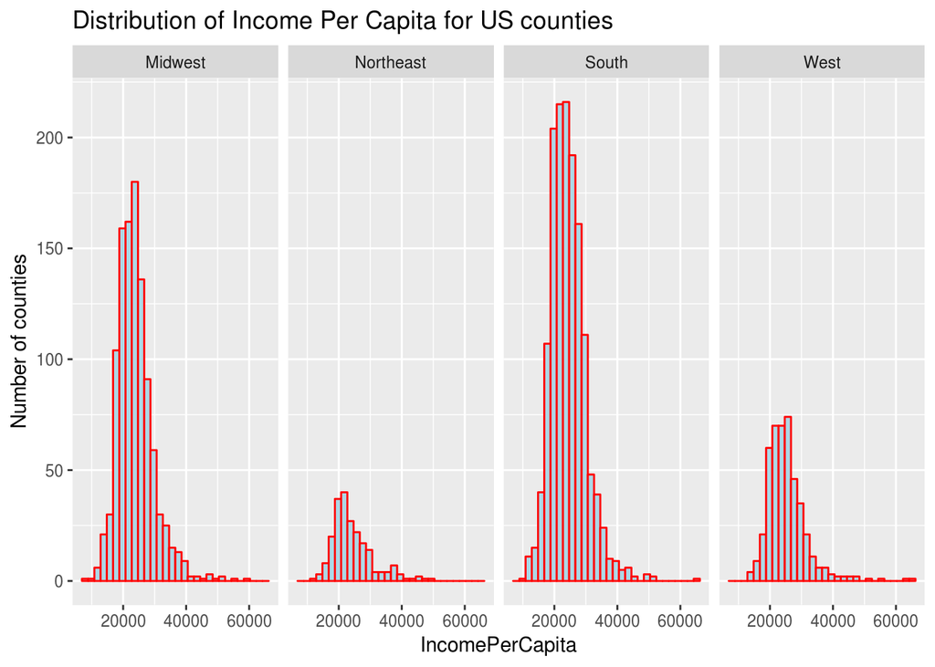

```r
ggplot(data=county_df, aes(county_df$IncomePerCap)) +
  geom_histogram(colour ="Red", fill ="light blue") +
  labs(title="Distribution of Income Per Capita for US counties" ,x="IncomePerCapita",y="Number of counties") +
  facet_grid(. ~ Region)
```

### Problem 6 - Basic bar chart

Create a bar chart showing the number of counties by Region in the US. Make sure your graph has a title and good axis labels.

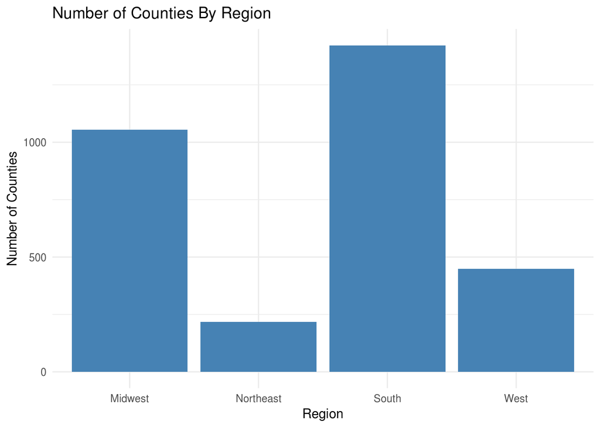

```r
ggplot(county_df,aes(x = county_df$Region)) +
  geom_bar(fill="steel blue") +
  labs(title = "Number of Counties By Region", x="Region" , y="Number of Counties") +
  theme_minimal()
```

### Problem 7 - Basic scatter plots

Create a scatter plot using the Michigan only data frame comparing Income and MeanCommute.

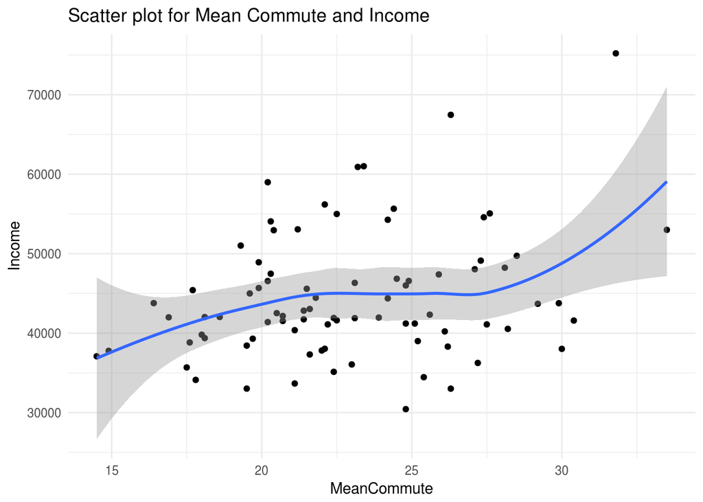

```r
ggplot(county_MI,aes( y =county_MI$Income,x=county_MI$MeanCommute)) +
  geom_point() +
  labs(title = "Scatter plot for Mean Commute and Income", x="MeanCommute" , y="Income") +
  theme_minimal()+
  geom_smooth()
```

```r
cor(county_MI$Income,county_MI$MeanCommute)
```

```
## [1] 0.2740689
```

Create a modified version of the above scatter plot in which the point color is mapped to peninsula.

### Relationship between Income and MeanCommute

**The correlation relation is not strong enough,but a positive trend can be noticed for the variables,** **for UP The Income range is lower with less commute time,while for LP the income range is higher with greater commute time as compared to UP.**

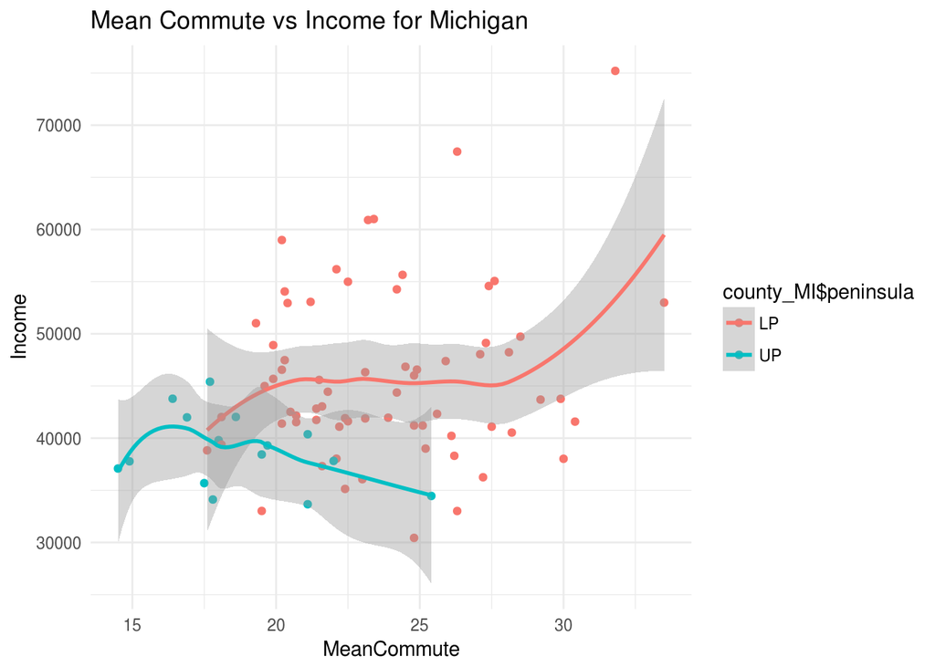

```r
ggplot(county_MI,aes(color=county_MI$peninsula,y = county_MI$Income,x= county_MI$MeanCommute)) +
  geom_point() +
  labs(title = "Mean Commute vs Income for Michigan", x="MeanCommute" , y="Income") +
  geom_smooth()+
  theme_minimal()
```

Now, create a few more scatter plots using variables of your choosing in which you facet by peninsula as well. How do the relationships compare across the peninsulas?

**A strong trend can be observed via the scatter plot for these two pairs:**

**1. Public Work and Employed : these variables seems to have a negative relation for both the peninsulas,counties with higher public work percentage has lower employment rate,this relation is stronger for the LP than the UP**

**2.Asian and Employed : variables seems to have a positve relation for both the peninsulas,counties with higher percentage of Asian population has a higher employment rate,this relation is stronger for the LP than the UP,in this case too the relation is stronger for LP than the UP**

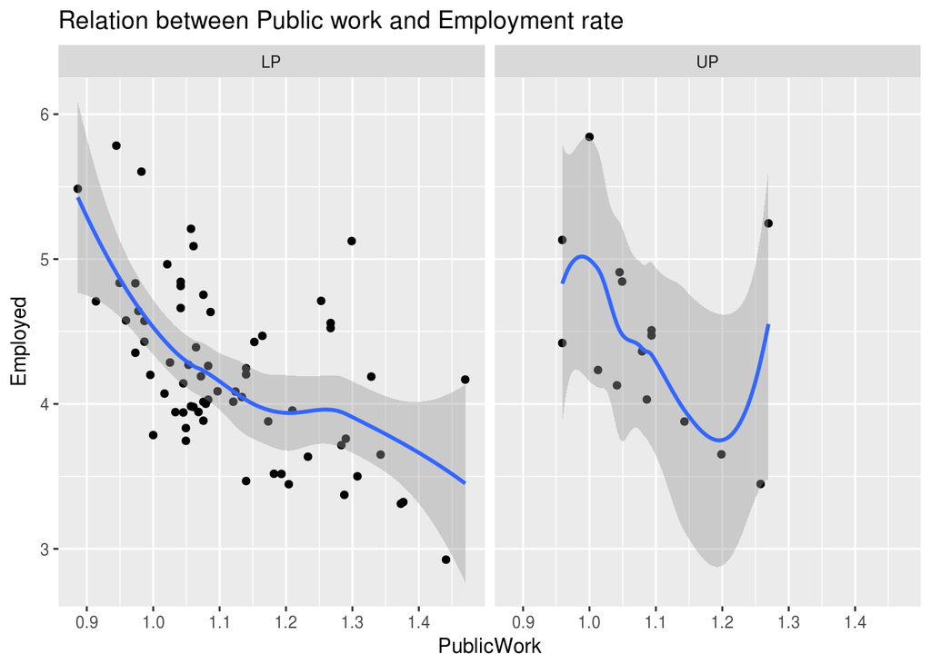

```r
ggplot(county_MI,aes(x=  log10(county_MI$PublicWork) ,y =log10(county_MI$Employed) )) +
  geom_point() +
  labs(title = "Relation between Public work and Employment rate", x="PublicWork" , y="Employed") +
  geom_smooth()+
  facet_grid(~ county_MI$peninsula)
```

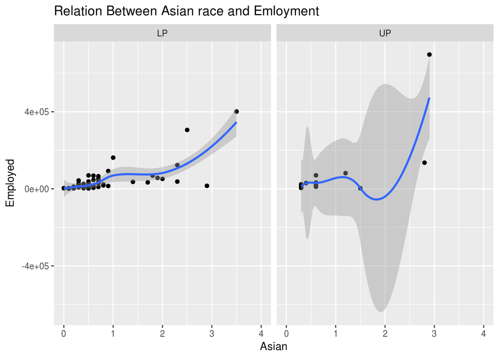

```r
ggplot(county_MI,aes(x= (county_MI$Asian),y = county_MI$Employed  )) +
  geom_point() +
  labs(title = "Relation Between Asian race and Emloyment", x="Asian" , y="Employed") +
  geom_smooth()+
    xlim(0, 4)+
  facet_grid(~ county_MI$peninsula)
```

Now use the full US data frame.

Create a scatter plot of TotalPop by Income.

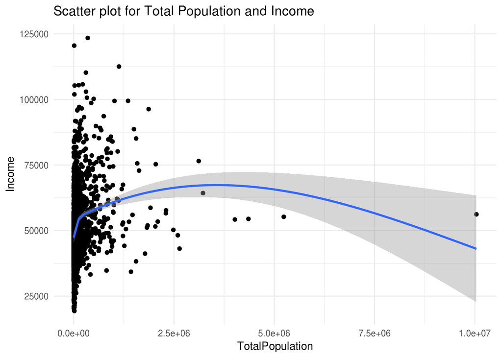

```r
#Wihout Log scale
ggplot(county_df,aes( y = (county_df$Income),x= (county_df$TotalPop) )) +
  geom_point() +
  labs(title = "Scatter plot for Total Population and Income", x="TotalPopulation" , y="Income") +
  theme_minimal()+
  geom_smooth()
```

```r
cor(county_df$TotalPop,county_df$Income)
```

```
## [1] 0.2404745
```

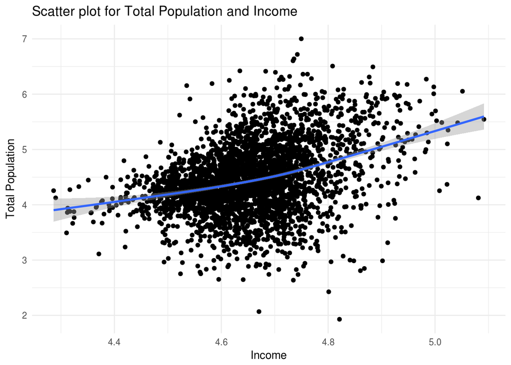

```r
#With Log Scale
ggplot(county_df,aes( y = log10(county_df$TotalPop),x= log10(county_df$Income) )) +
  geom_point() +
  labs(title = "Scatter plot for Total Population and Income", x="Income" , y="Total Population") +
  theme_minimal()+
  geom_smooth()
```

```r
cor(log10(county_df$TotalPop),log10(county_df$Income))
```

```
## [1] 0.3394912
```

### Relation between Total Popluation and Income

**The total population and Income do not seem to show any strong relation, although plotting the data makes it improved the pattern for the scatter,and it shows somewhat positive trend.** **The correlation coeffienct also shows no stronger relation between the two variable**

### Why Log Scale??

- **There are a few data points those have very large numbers for total population that differs greatly from rest to the data points.**
- **These outlier makes the graph look skewed to the right,also the compressed data points makes it difficult to notice small changes and bias the the judgement of the pattern.**
- **The difference between the outliers and other data points is huge,this difference will hence domiate the difference between the other data - points when plotted on a normal scale.**
- **Log scale on the other hand plots the ratio rather than the difference ,it normalized the exponential data.**
- **Since the data for Income is in orders of magnitude,using log scale wil help getting the whole data on one axis.**
- **The log scale improves the correlation coeffienct for the variables,it also improves the pattern.**

### Hacker Extra - More analysis

Do some additional plotting to look for interesting patterns or relationships either in the full US dataset or the MI only dataset. In addition, try out some of ggplots additional features such as themes, axis formatting, gridline control, or others.

**I did a Correlation Matrix of a few variables,out of which Income,Professionals has a positive correlation.** **Also another pairs of interest for Michigan data me were Type of Work (Public,Private) with % that use Walking as means of Commute,there is a positive** **Correlation for Public work and Walk while Negative for Private and Walk ,this suggest that people working in Private sector domiated the** **drive percentage of commute method while those working in Public sector use walking as means of commute** **Correlation Matrix**

```r
Cordata <-county_df[,c(7,17,23:28,31,34,36,37)]
CorDatMI<- county_MI[,c(8,18,24:29,32,35,37,38)]
cor(Cordata)
```

```
##                  TotalPop      Income  Professional      Service
## TotalPop      1.000000000  0.24047450  0.2479737559  0.004179506
## Income        0.240474503  1.00000000  0.6020964177 -0.351331682
## Professional  0.247973756  0.60209642  1.0000000000 -0.260658875
## Service       0.004179506 -0.35133168 -0.2606588753  1.000000000
## Office        0.195665574  0.13449867  0.0008051148 -0.028760462
## Construction -0.266158918 -0.22702857 -0.3790876188 -0.120257596
## Production   -0.188138899 -0.35687260 -0.6710131728 -0.227191332
## Drive        -0.101692525 -0.13659915 -0.2726395021 -0.056786367
## Walk         -0.047149234  0.05566887  0.1847318756  0.048316476
## MeanCommute   0.155725529  0.11846367 -0.0954089729 -0.052303766
## PrivateWork   0.196202447  0.19226487 -0.1945729118 -0.195070935
## PublicWork   -0.141302101 -0.18954736  0.1165563991  0.332460369
##                     Office Construction  Production       Drive
## TotalPop      0.1956655739  -0.26615892 -0.18813890 -0.10169253
## Income        0.1344986669  -0.22702857 -0.35687260 -0.13659915
## Professional  0.0008051148  -0.37908762 -0.67101317 -0.27263950
## Service      -0.0287604617  -0.12025760 -0.22719133 -0.05678637
## Office        1.0000000000  -0.43745111 -0.20285150  0.27517478
## Construction -0.4374511050   1.00000000 -0.00359040 -0.14508072
## Production   -0.2028515043  -0.00359040  1.00000000  0.29629317
## Drive         0.2751747773  -0.14508072  0.29629317  1.00000000
## Walk         -0.2592733146   0.11304355 -0.17820181 -0.76438471
## MeanCommute   0.1588131976  -0.03798177  0.08065891  0.22272483
## PrivateWork   0.3527838280  -0.30562956  0.37160047  0.42678099
## PublicWork   -0.1981227004   0.13246325 -0.32622501 -0.27319901
##                     Walk MeanCommute PrivateWork PublicWork
## TotalPop     -0.04714923  0.15572553   0.1962024 -0.1413021
## Income        0.05566887  0.11846367   0.1922649 -0.1895474
## Professional  0.18473188 -0.09540897  -0.1945729  0.1165564
## Service       0.04831648 -0.05230377  -0.1950709  0.3324604
## Office       -0.25927331  0.15881320   0.3527838 -0.1981227
## Construction  0.11304355 -0.03798177  -0.3056296  0.1324633
## Production   -0.17820181  0.08065891   0.3716005 -0.3262250
## Drive        -0.76438471  0.22272483   0.4267810 -0.2731990
## Walk          1.00000000 -0.42320679  -0.3969997  0.2998672
## MeanCommute  -0.42320679  1.00000000   0.2649171 -0.1439659
## PrivateWork  -0.39699975  0.26491711   1.0000000 -0.8471688
## PublicWork    0.29986718 -0.14396588  -0.8471688  1.0000000
```

```r
cor(CorDatMI)
```

```
##                TotalPop     Income  Professional     Service       Office
## TotalPop      1.0000000  0.3437119  0.4288742438 -0.21370932  0.157658025
## Income        0.3437119  1.0000000  0.7051684362 -0.58465608  0.106681902
## Professional  0.4288742  0.7051684  1.0000000000 -0.27803488 -0.039454691
## Service      -0.2137093 -0.5846561 -0.2780348848  1.00000000 -0.107987738
## Office        0.1576580  0.1066819 -0.0394546908 -0.10798774  1.000000000
## Construction -0.5077288 -0.4463706 -0.6903121965  0.06963327 -0.107007923
## Production   -0.1730073 -0.2519382 -0.6308643844 -0.36256217 -0.288392698
## Drive         0.2203444  0.3299380 -0.0005494885 -0.48732330  0.362527930
## Walk         -0.2169510 -0.3300208  0.1052481533  0.45784316 -0.330682540
## MeanCommute   0.1541148  0.2740689 -0.1339215767 -0.35187886  0.008701965
## PrivateWork   0.3858513  0.4467042  0.1089956934 -0.63949845  0.238397048
## PublicWork   -0.2495982 -0.3584105  0.0384308594  0.62988010 -0.215044624
##              Construction Production         Drive        Walk
## TotalPop      -0.50772878 -0.1730073  0.2203444381 -0.21695096
## Income        -0.44637059 -0.2519382  0.3299379648 -0.33002083
## Professional  -0.69031220 -0.6308644 -0.0005494885  0.10524815
## Service        0.06963327 -0.3625622 -0.4873233032  0.45784316
## Office        -0.10700792 -0.2883927  0.3625279297 -0.33068254
## Construction   1.00000000  0.3055100 -0.1074889626 -0.04760561
## Production     0.30550996  1.0000000  0.2376530150 -0.27435411
## Drive         -0.10748896  0.2376530  1.0000000000 -0.73366183
## Walk          -0.04760561 -0.2743541 -0.7336618332  1.00000000
## MeanCommute    0.25933620  0.2739056  0.3033125037 -0.48307961
## PrivateWork   -0.19100750  0.3148369  0.6621010420 -0.56698083
## PublicWork    -0.01051016 -0.3898898 -0.5661231427  0.60573792
##               MeanCommute PrivateWork  PublicWork
## TotalPop      0.154114772   0.3858513 -0.24959816
## Income        0.274068895   0.4467042 -0.35841053
## Professional -0.133921577   0.1089957  0.03843086
## Service      -0.351878864  -0.6394985  0.62988010
## Office        0.008701965   0.2383970 -0.21504462
## Construction  0.259336201  -0.1910075 -0.01051016
## Production    0.273905618   0.3148369 -0.38988985
## Drive         0.303312504   0.6621010 -0.56612314
## Walk         -0.483079605  -0.5669808  0.60573792
## MeanCommute   1.000000000   0.3341100 -0.41441612
## PrivateWork   0.334109967   1.0000000 -0.93253319
## PublicWork   -0.414416119  -0.9325332  1.00000000
```

**The Relation between Total Population to Income looks better for Michigan only data as compared to the US data set**

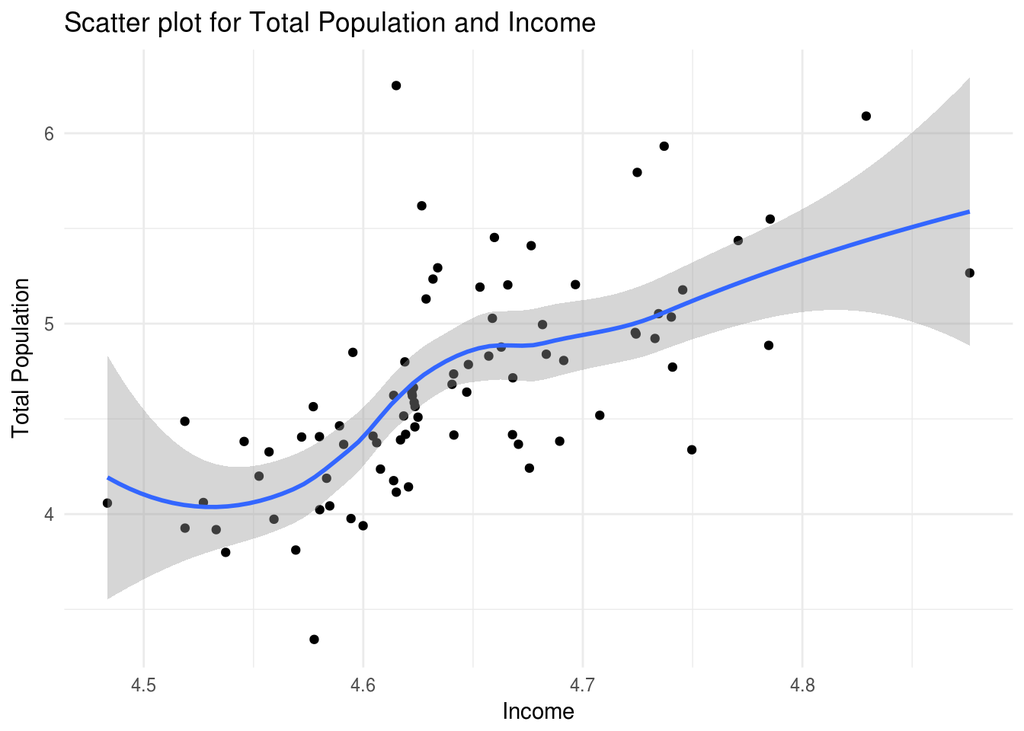

```r
ggplot(county_MI,aes( y = log10(county_MI$TotalPop),x= log10(county_MI$Income) )) +
  geom_point() +
  labs(title = "Scatter plot for Total Population and Income", x="Income" , y="Total Population") +
  theme_minimal()+
  geom_smooth()
```